# How do host plant use and seasonal life cycle relate to insect body size: A case study on European geometrid moths (Lepidoptera: Geometridae) - Seifert - 2023 - Journal of Evolutionary Biology - Wiley

[Journal of Evolutionary Biology](https://onlinelibrary.wiley.com/journal/14209101)

[Volume 36, Issue 5](https://onlinelibrary.wiley.com/toc/14209101/2023/36/5) p. 743-752

[figure not shown]

RESEARCH ARTICLE

Open Access

# How do host plant use and seasonal life cycle relate to insect body size: A case study on European geometrid moths (Lepidoptera: Geometridae)

[Carlo L. Seifert](https://onlinelibrary.wiley.com/authored-by/ContribAuthorRaw/Seifert/Carlo+L.),

[Patrick Strutzenberger](https://onlinelibrary.wiley.com/authored-by/ContribAuthorRaw/Strutzenberger/Patrick),

[Konrad Fiedler](https://onlinelibrary.wiley.com/authored-by/ContribAuthorRaw/Fiedler/Konrad),

First published: 23 March 2023

https://doi.org/10.1111/jeb.14169

## Abstract

We used European geometrid moths (>630 species) as a model group to investigate how life history traits linked to larval host plant use (i.e., diet breadth and host-plant growth form) and seasonal life cycle (i.e., voltinism, overwintering stage and caterpillar phenology) are related to adult body size in holometabolous insect herbivores. To do so, we applied phylogenetic comparative methods to account for shared evolutionary history among herbivore species. We further categorized larval diet breadth based on the phylogenetic structure of utilized host plant genera. Our results indicate that species associated with woody plants are, on average, larger than herb feeders and increase in size with increasing diet breadth. Obligatorily univoltine species are larger than multivoltine species, and attain larger sizes when their larvae occur exclusively in the early season. Furthermore, the adult body size is significantly smaller in species that overwinter in the pupal stage compared to those that overwinter as eggs or caterpillars. In summary, our results indicate that the ecological niche of holometabolous insect herbivores is strongly interrelated with body size at maturity.

## 1 INTRODUCTION

Adult body size is a key characteristic of any insect species as it affects a range of fitness-related traits, such as fecundity (García-Barros, 2000; Whitman, 2008), longevity (Holm et al., 2016, 2022) and dispersal ability (Freire et al., 2021; Sekar, 2012). Hence, the identification of life-history traits related to body size is essential to deepen our understanding of how such conspicuous interspecific variation in insect body size has evolved.

In holometabolous insects, interspecific differences in body size could result from a wide array of selective forces, such as resource quality during larval development (Mattson, 1980) or predation pressure (Tammaru et al., 2018). Host plant taxa, for instance, differ in their quality as a food source for herbivorous insects due to substantial variation in nutrient and water content (Kerkhoff et al., 2006; Mattson, 1980; Segarra-Carmona & Barbosa, 1983), secondary metabolites (Moore et al., 2014) and physical defence mechanisms (Fordyce et al., 2010; Lill et al., 2009). Previous studies have suggested that having a larger body size increases the tolerance to withstand low host plant quality (e.g., Hochuli, 2001; Mattson, 1980; Zalucki et al., 2002), which in turn should lead to a positive relationship between body size and diet breadth. Yet, this hypothesis has received mixed support. Although some studies found a positive relationship (e.g., Brändle et al., 2000; Davis, Õunap, et al., 2012; Freire et al., 2021), others did not (e.g., García-Barros, 2000) or considered it a coincidental side effect (Novotný & Basset, 1999). Some earlier studies also reported that insect species associated with herbs are overall smaller than those feeding on woody plants (e.g., Bartonová et al., 2014; Lindström et al., 1994). They attributed this pattern mainly to growth-form-related differences in plant apparency (i.e., small, short-lived herbs vs. large and long-lived woody plants) and their hypothesized consequences for the production of defensive secondary plant metabolites (see Feeny, 1976; Smilanich et al., 2016). However, whether host-plant growth form influences the body size—diet breadth relationship is still unknown (see Davis, Õunap, et al., 2012).

Selective forces on body size change tremendously throughout the vegetation period, especially in regions with a pronounced seasonality. For instance, the nutritional quality of deciduous tree foliage is generally highest early in the season and declines strongly with progressing leaf maturation and senescence (Barton et al., 2019; Kause et al., 2001; Mattson, 1980; Zehnder et al., 2009). Leaf maturation is further accompanied by changes in secondary chemistry and other defence mechanisms (Barton et al., 2019; Prinsloo & Nogemane, 2018; Salminen et al., 2001, 2004). Moreover, predation pressure can vary substantially among different parts of the vegetation period (Drozdová et al., 2013; Remmel et al., 2009; Remmel & Tammaru, 2009). These examples illustrate that insect larvae developing during different parts of the season are exposed to fairly distinctive environmental conditions (e.g., Kause et al., 2001). The seasonal timing of a species' larval development, which is strongly related to a set of further life-cycle traits such as voltinism and overwintering stage, thus represents another important aspect to understand body size adaptations or constraints in insect herbivores. For instance, the capability to produce multiple generations per year was reported to be associated with smaller body sizes (Teder, 2020; Zeuss et al., 2017). Feeding in seasons of overall lower food quality might further select against large sizes because low-quality food leads to prolonged development times and thus increases mortality risk. Species developing early in the season could thus be assumed to be larger than those feeding in the late season.

As at least one generation of those species which overwinter as egg or larva belongs to the early season fauna, they could be further assumed to be generally larger than species overwintering as a pupa. However, to what extent ‘seasonal life strategies’ (e.g., voltinism, overwintering stage and caterpillar phenology) are related to adult body size in herbivorous insects has received comparably little attention (e.g., García-Barros, 2000; Teder, 2020; Zeuss et al., 2017).

Most previous studies investigating relationships between life-history traits and insect body size did not account for phylogenetic dependencies among species based on a solid, time-calibrated phylogeny (e.g., Davis, Õunap, et al., 2012; Tammaru et al., 2018). Insect body size, however, is a strongly conserved trait (Chown & Gaston, 2010; Désamoré et al., 2018; Freire et al., 2021; Seifert, Strutzenberger, & Fiedler, 2022), which implies that phylogenetically closely related taxa tend to be more similar in size than distantly related taxa. Implementing phylogenetic information is therefore crucial to further our understanding of general relationships among species traits and to evaluate their robustness.

In this study, we aimed at investigating whether ecological traits related to larval host plant use and seasonal life cycle are linked to adult body size in insect herbivores. European geometrid moths were used as a model system. We formulated five hypotheses, which were tested while controlling for phylogenetic dependence among species:

1. Body size increases with increasing diet breadth (i.e., decreasing dietary specialization) of a species.
2. Species that feed exclusively on herbaceous plants are smaller than those which are obligatorily or facultatively associated with woody plants.
3. Univoltine species are larger than multivoltine species.
4. Species that overwinter as a pupa are smaller than those that overwinter in the egg or larval stage.
5. Species whose caterpillars develop exclusively in the early season are larger than those developing in later parts of the season.

We further explored whether a possible body size—diet breadth relationship is host-plant growth form specific or applies equally to herb and woody plant feeders.

## 2 METHODS

### The target fauna

We used a previously published trait database of European geometrid moths comprising 631 species (Seifert, Strutzenberger, & Fiedler, 2022; https://doi.org/10.5061/dryad.sbcc2fr8m). The geometrid species included in this dataset mostly correspond with the species treated in the ‘Geometrid Moths of Europe’ (GME) series (Hausmann, 2001). However, species restricted to Northern Africa, to regions east of 30° longitude and/or Turkey as well as those taxa whose larvae are not herbivores sensu stricto (e.g., detritivorous or lichenivorous species) were not included in this database. Furthermore, the whole subfamily Sterrhinae (>200 spp. in Europe) was omitted as many species of this group (especially the speciose genus *Idaea* Treitschke, 1825) feed on dead plant material and are thus no ‘classical’ herbivores (s. str.) (for more details on species selection see Seifert, Strutzenberger, & Fiedler, 2022; Seifert, Strutzenberger, Hausmann, et al., 2022). Yet, the subset of Geometridae subfamilies included in our study still represents a monophylum (Murillo-Ramos et al., 2019; Rajaei et al., 2022; Sihvonen et al., 2020).

For species considered in this database, we compiled information on adult body size, larval host plant use (i.e., dietary specialization and host-plant growth form) and seasonal life cycle (i.e., voltinism, overwintering stage and caterpillar phenology). Information on body size, host plant use and voltinism was directly extracted from the aforementioned trait database and, in the case of dietary specialization, slightly modified (see below). Information on overwintering stage and caterpillar phenology were additionally extracted from the GME monographic series (Hausmann, 2001; Hausmann & Viidalepp, 2012; Mironov, 2003; Müller et al., 2019; Skou & Sihvonen, 2015) and occasionally supplemented using reliable online sources (Appendix S1).

### Species traits

‘Body size’ was measured as the arithmetic mean of minimum and maximum adult wingspan (in mm). In Lepidoptera, the adult body size is strongly correlated with egg size, final larval size and pupal size (e.g., Davis, Javoiš, et al., 2012; García-Barros, 2000). Hence, size measures on adults can serve as a meaningful proxy for relative size differences in other life stages as well. Wingspan was averaged across generations (for multivoltine species) and across populations (and subspecies) occurring in the defined region. Whenever size dimorphism was indicated in the GME series, only measures on male specimens were considered to avoid distortion due to sexual size dimorphism (see Seifert, Strutzenberger, & Fiedler, 2022), which can be highly pronounced in geometrid moths. In a number of species, for instance, females are flightless due to extreme wing reduction (i.e., aptery and brachyptery). By contrast, the males of all geometrid species have fully developed wings and are capable of flight, which makes them more suitable for interspecific comparisons of wingspan.

We classified ‘larval dietary specialization’ (i.e., larval diet breadth) using mean phylogenetic pairwise distance (MPD) as presented in the database by Seifert, Strutzenberger, and Fiedler (2022). These values represent the average distance between pairs of host plant genera utilized by a particular geometrid species. Hence, this measure of diet breadth incorporates a phylogenetic component, rather than simply the number of host taxa used. As a result, our metric is less sensitive to incomplete host plant lists. The calculation of MPD values was based on reliable host plant information (field observations) as specified in the GME series. Doubtful records, speculative host plant associations, as well as feeding observations on neophytes, were not considered (for further information on the MPD calculation see Seifert, Strutzenberger, & Fiedler, 2022; Seifert, Strutzenberger, Hausmann, et al., 2022). Since the frequency distribution of MPD suggested the existence of three distinct ‘diet breadth groups’ (see Appendix S2), we used larval diet breadth as a categorical variable. Accordingly, geometrid species were categorized as either monophages, oligophages or polyphages. We defined ‘monophages’ as species with an MPD value of zero (i.e., larvae feeding on one single plant genus only). To determine an empirical threshold between oligophagous and polyphagous species, we used kernel density estimates of MPD values, considering those species whose larvae feed on more than one plant genus (i.e., MPD >0). Density estimates were calculated in R v. 4.1.0 environment (R Core Team, 2021), using the default settings of the ‘density’ function. We then calculated the local minimum between the two largest modes of the probability density function (i.e., 47 < MPD ≤ 219; see Appendix S2). This local minimum value (MPD = 122) was then used to delineate oligophagous species (MPD < 122) from polyphagous species (MPD ≥ 122). This way, we ensured that the chosen threshold between oligophagous and polyphagous taxa separates two naturally discernible ‘diet breadth groups’ and hence is not entirely arbitrary (Appendix S2). Contrary to many studies that employ arbitrarily predefined diet breadth categories based on host plant taxonomy (for discussion see Jorge et al., 2014; Symons & Beccaloni, 1999), our approach does not, except for monophagous species (where the problem of arbitrary delineation is not applicable), strictly rely on the taxonomic classification system. For example, moth species associated with a single but phylogenetically heterogeneous plant family (e.g., Rosaceae) could be considered polyphagous if their larvae feed on distantly related host genera within this family.

With regard to the ‘host-plant growth form’, three categories were distinguished: herb feeders (taxa whose caterpillars are associated with forbs, ferns and/or graminoids), woody plant feeders (species whose larvae feed obligatorily on woody plants such as trees, shrubs, dwarf shrubs and lignifying lianas) and indiscriminate feeders (species whose larvae feed on both herbaceous plants as well as on woody plants). Grasses, rushes and sedges (all Poales) differ substantially from forbs in terms of growth, morphology and defence mechanisms (Tscharntke & Greiler, 1995). Species feeding on these plants are therefore often classified as a separate group, viz. ‘grass-feeders’. Nevertheless, we decided to assign them to the herb feeders due to the following reasons: Firstly, only nine geometrid species included in our study have been recorded to feed on such plants. Secondly, all of them predominantly feed on non-graminoid forbs, which hints to the assumption that graminoids play a negligible role as a food source during larval development. Not a single geometrid species in Europe has thus far been recorded as a specialist on graminoids.

‘Voltinism’ indicates the maximum number of generations per year within the study area. Hence, geometrid species were classified as either univoltine (including semivoltine taxa) or multivoltine (including taxa with a partial second generation).

We further categorized the species according to their ‘overwintering stage’, that is, overwintering in the egg, larval, pupal or adult stage. Species that are able to overwinter in multiple stages (*N* = 14) were not classified. In addition, species overwintering exclusively as adults were not considered for further analyses as they were represented in eight species only.

Regarding ‘caterpillar phenology’, we distinguished among species whose caterpillars develop exclusively in the spring/early summer and those whose larvae develop in the summer/late summer season. This distinction is particularly relevant for species associated with woody plants as it separates the vegetation period according to the availability of young, nutrient-rich foliage in the early season versus mature, nutrient-poor foliage in the late season (e.g., Kause et al., 2001; Seifert et al., 2021; Zehnder et al., 2009). To achieve this distinct seasonal separation, we focused only on species with a strictly univoltine life cycle and excluded taxa that overwinter as larvae. Those species whose caterpillars occur around the time of leaf flush in April or May and finish their development at the latest in June (exceptionally: early July) were considered ‘early season’ species. Information on the seasonal occurrence of species typical for the early season (i.e., *Alsophila aescularia* ([Denis & Schiffermüller], 1775), *Epirrita autumnata* (Borkhausen, 1794), *Erannis defoliaria* (Clerck, 1759) and *Operopthera brumata* (L., 1758)) served as a reference to define this group. All other univoltine taxa were considered ‘late season’ species as their larvae do usually not occur before July (exceptionally end of June) and develop until August, September or even October. Nevertheless, climate, season length and host plant phenology differ strongly across Europe, depending on latitude and altitude. To ensure that information on larval phenology (i.e., months of larval occurrence as mentioned in the GME series) is comparable among species, we reduced the species list and considered only geometrid taxa whose distributional range includes regions with a fully humid, warm temperate climate (Cf) in Europe, according to the Köppen–Geiger classification (see Kottek et al., 2006). To achieve this, we selected only species occurring from 47° N to 58° N and omitted all taxa which are restricted to mountain ranges (i.e., northern Alps, Carpathian Mountains), using the information on latitudinal distribution and mountain endemism as provided by Seifert, Strutzenberger, Hausmann, et al. (2022).

### Statistical analyses

All statistical analyses described below were conducted in R v. 4.1.0 environment (R Core Team, 2021). To test our hypotheses, we applied phylogenetic comparative methods. These methods allowed us to account for the non-independence of model residuals due to shared evolutionary history (Felsenstein, 1985; Martins & Hansen, 1997). To do so, we used a previously published molecular phylogeny (Seifert, Strutzenberger, Hausmann, et al., 2022), based on mitochondrial COI barcode sequences and seven nuclear genes (for 17% of the species). This tree was built using sequence data, time calibration and lineage constraints obtained from previous studies (Ghanavi, 2020; Murillo-Ramos et al., 2019; for details see Seifert, Strutzenberger, Hausmann, et al., 2022) and includes all species treated in our study.

The number and identity of species for which individual predictor variables were available differed. Specifically, information on the overwintering stage and caterpillar phenology covered only 538 (85.3%) and 138 (21.9%) of the 631 species treated in the original database. Some of the predictor variables are further highly intercorrelated, violating basic assumptions for multiple regression analyses. For instance, any indiscriminate feeder utilizes at least two plant genera which by default excludes the possibility to be classified as a monophagous species at the same time. It was therefore not feasible to build one global statistical model which considers all predictor variables simultaneously. Hence, we decided to conduct bivariate analyses, that is, testing the relationship between body size and each predictor variable separately using the respective set of species. As our predictor variables (i.e., dietary specialization, host-plant growth form, voltinism, overwintering stage and caterpillar phenology) are all categorical, we used simulation-based phylogenetic analysis of variances (ANOVAs; Garland et al., 1993; Revell, 2012). These phylogenetic ANOVAs represent equivalents to the traditional one-way ANOVA, with the exception that they account for evolutionary dependencies among species (Rohlfs & Nielsen, 2015). All phylogenetic ANOVA models were fitted using the ‘phylANOVA’ function as implemented in the *phytools* package (Revell, 2012) and based on 20 000 simulations. For post-hoc tests among group means, we used Holm-Bonferroni *p*-value correction in case of multiple comparisons. In every model, the log<sub>10</sub>-transformed wingspan was used as a response variable.

Lepidoptera associated with herbs were previously hypothesized to be more specialized compared to those which feed exclusively on woody plants (e.g., Futuyma, 1976; Niemelä et al., 1982). We therefore investigated whether a possible body size—diet breadth relationship is driven just by one of these groups. To do so, we analysed obligatory herb feeders and obligatory woody plant feeders separately, although excluding species feeding on both host plant groups (i.e., indiscriminate feeders). For these tests, we applied phylogenetic ANOVA approaches as described before.

## 3 RESULTS

### Effects of larval host plant use on adult body size

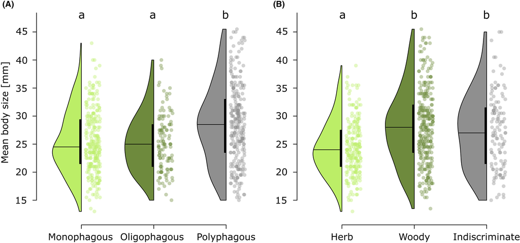

**FIGURE 1**

Differences in mean body size (male wingspan) of European geometrid moths in dependence of their (A) larval dietary specialization and (B) larval host-plant growth form. Black vertical bars represent interquartile ranges. Different letters indicate significance.

TABLE 1. Mean (±SE), interspecific variance and coefficient of variation (CV) for adult body size of European geometrid moths.

| Predictor | Category | Mean ± SE (mm) | Variance (mm<sup>2</sup>) | CV (%) | *N* |
| --- | --- | --- | --- | --- | --- |
| Dietary specialization | Monophagous | 25.4 ± 0.4 | 31.5 | 22.2 | 254 |
|  | Oligophagous | 25.3 ± 0.5 | 26.3 | 20.4 | 119 |
|  | Polyphagous | 28.6 ± 0.4 | 48.8 | 24.5 | 258 |
| Host-plant growth form | Herb | 24.4 ± 0.3 | 23.8 | 20.0 | 218 |
|  | Indiscriminate | 27.4 ± 0.6 | 45.1 | 24.5 | 118 |
|  | Woody plant | 28.1 ± 0.4 | 44.3 | 23.7 | 295 |
| Voltinism | Univoltine | 27.6 ± 0.3 | 41.6 | 23.4 | 341 |
|  | Multivoltine | 25.6 ± 0.4 | 36.3 | 23.6 | 290 |
| Overwintering stage | Egg | 29.1 ± 0.7 | 34.2 | 20.1 | 75 |
|  | Larva | 29.7 ± 0.5 | 36.4 | 20.3 | 170 |
|  | Pupa | 24.2 ± 0.3 | 33.5 | 23.9 | 293 |
| Caterpillar phenology | Early season | 28.4 ± 0.7 | 37.5 | 21.5 | 77 |
|  | Late season | 24.3 ± 0.8 | 40.0 | 26.0 | 61 |

- *Note*: Values are separated by life-history traits related to host plant use (i.e., dietary specialization and host-plant growth form) and seasonality (i.e., voltinism, overwintering stage and caterpillar phenology). Values refer to male wingspans only (see Section 2).
- Abbreviation: SE, standard error.

Mean body size varied depending on host-plant growth form (*F*<sub>2,628</sub> = 22.0, *p* = 0.007). Species feeding exclusively on herbs were found to be smaller than those whose caterpillars are facultatively (*t* = −4.03, *p* = 0.044) or obligatorily (*t* = −6.51, *p* = 0.02) associated with woody plants (Figure 1B; Table 1). No significant difference in body size was found between species that feed either facultatively or obligatorily on woody plants (*t* = −1.12, *p* = 0.38).

### Seasonal life-cycle effects on adult body size

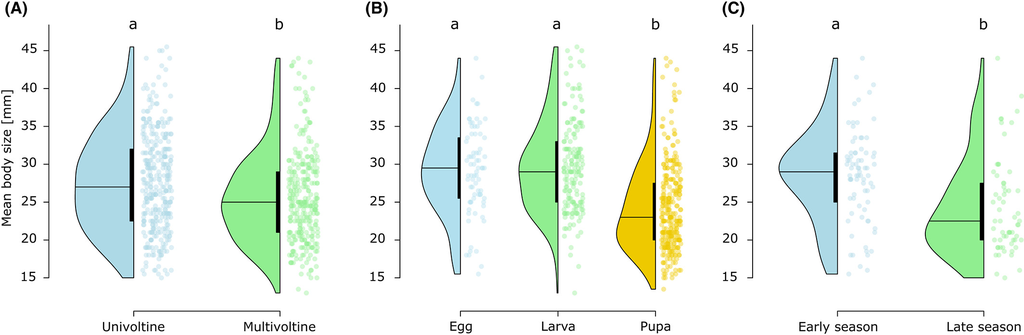

**FIGURE 2**

Differences in mean body size (male wingspan) of European geometrid moths in dependence of their (A) voltinism, (B) overwintering stage and (C) caterpillar phenology (i.e., time of larval development). Black vertical bars represent interquartile ranges. Different letters indicate significance.

## 4 DISCUSSION

In this study, we investigated whether life-history traits linked to host plant use and seasonal life cycle are related to adult body size within a monophyletic, species-rich group of holometabolous insect herbivores. Our results suggest that all studied life history traits (i.e., larval dietary specialization, host-plant growth form, voltinism, overwintering stage and caterpillar phenology) are significantly related to adult body size. We further show that the body size—diet breadth relationship is not universal but rather depends on host-plant growth form. Compared to most of the previous studies examining body size—life history relationships, we accounted for phylogenetic dependencies among species and thus a priori excluded the possibility that any of the observed relationships is a pure consequence of phylogenetic trait conservatism.

### Relationships between host plant use and adult body size

In line with our first hypothesis, we observed that polyphagous geometrid species are larger in their adult stage than monophagous or oligophagous species, which accords with a range of previous studies—most of them lacking phylogenetic control—on phytophagous insects (e.g., Brändle et al., 2000; Davis, Õunap, et al., 2012; Gaston & Reavey, 1989; Lindström et al., 1994; Loder et al., 1998; Novotný & Basset, 1999; but see García-Barros, 2000; Komonen et al., 2004 for butterflies). Hence, our finding supports the widely shared idea that larger body sizes in herbivorous insect larvae increase their tolerance to low-quality food, for example, lower nutritional value or increased leaf toughness (Čížek, 2005; Hochuli, 2001; Mattson, 1980; Reavey, 1993; Zalucki et al., 2002), which in turn would allow to utilize a wider array of host plants.

Notably, when herb feeders and woody plant feeders were analysed separately, the observed relationship between diet breadth and body size was retained only for species associated with woody plants. This finding indicates that even within a monophyletic group of insect herbivores, the diet breadth—body size relationship is not a universal pattern. As we controlled for phylogeny, we can exclude the possibility that this finding is an artefact caused by speciose clades of small-sized species which are predominantly associated with herbs (e.g., Eupitheciini).

We further found clear evidence that herb-feeding geometrid species are smaller than those which are facultatively or obligatorily associated with woody plants. This finding corresponds with previous studies on butterflies (Bartonová et al., 2014; Čížek et al., 2006; García-Barros, 2000) and moths (Lindström et al., 1994), but which were done without controlling for relatedness based on a solid, time-calibrated molecular phylogeny. One possible explanation for this repeatedly documented pattern appears when these host plant groups are contrasted from a phytochemical perspective. Herbs commonly invest in qualitative defences (i.e., specific toxins such as alkaloids or glucosinolates). Many woody plants, by contrast, defend themselves primarily by quantitative defences such as condensed tannins (Bustamante et al., 2006; Feeny, 1976; Smilanich et al., 2016), which are indigestive. Furthermore, the foliage of herbs reveals on average higher nutrient contents compared to those of woody plants (Han et al., 2005; Kerkhoff et al., 2006; Zhang et al., 2018). Larger body sizes might thus be of advantage to overcome these quantitative defence mechanisms and reduced nutrient contents which are characteristic of woody plants (Čížek, 2005; Hochuli, 2001; Mattson, 1980; Reavey, 1993). Due to the lack of a diet breadth—body size relationship for herb feeders, our results do not suggest that larger body sizes provide a general advantage to circumvent qualitative defence mechanisms.

Apart from the phytochemical explanation, also other selective forces such as predation pressure may contribute to explaining size differences among herb and woody plant feeders. For instance, feeding on woody plants in forest habitats might lower the predation risk by natural enemies due to reduced detectability, as suggested by a range of experimental studies (e.g., Posa et al., 2007; Seifert et al., 2015). This would allow for longer development times of forest species and, in consequence, for larger body sizes.

### How seasonal life-cycle traits interrelate with adult body size

In line with our prediction, we found that potentially multivoltine species are, on average, smaller than strictly univoltine species. This corresponds with previous studies investigating body size–voltinism relationships across multiple families of European butterflies and moths (Teder, 2020; Zeuss et al., 2017). In European butterflies, species with larger body sizes were found to have longer larval development times (García-Barros, 2000). Hence, one explanation could be that longer development times of large species select against additional generations (see Bartonová et al., 2014). As the season must be split among generations in multivoltine species, increased time constraints might additionally select for faster larval development (Dennis et al., 2012) and, in consequence, against large body sizes.

According to our fourth hypothesis, we found that geometrid species that overwinter as pupa are significantly smaller than those overwintering as eggs or as larvae, which is consistent with a comprehensive study (without phylogenetic control) on more than 900 British Macrolepidoptera species (Gaston & Reavey, 1989). We further found that univoltine species feeding in the early season are on average larger than those developing in later parts of the growing season. The overwintering stage and larval phenology are strongly linked to each other. This results from the circumstance that the vast majority of species overwintering as egg or larva start feeding in early spring and thus constitute a substantial portion of the early season caterpillar fauna. However, since we excluded species overwintering as larvae from the phenological analyses, the results on the overwintering stage and larval phenology could be interpreted as complementary to each other.

Species overwintering as egg or larvae can develop (or complete their larval development) in the first part of the growing season when fresh, young leaves of high nutritional quality are available (e.g., on many shrubs and deciduous trees) (Awmack & Leather, 2002; Mattson, 1980). Geometrids overwintering as pupa, by contrast, have to pass the adult and egg stages before their caterpillars can start feeding. Apart from some species whose adults are on the wing early in the year before budburst, overwintering as pupa causes therefore some ‘seasonal delay’. Hence, many of these taxa develop later in the growing season. Due to various host-plant-related processes such as leaf maturation, drought stress and nutrient depletion, these species are most widely constrained to feed on plant tissue of substantially lower quality than species of the early season (Awmack & Leather, 2002; Kause et al., 2001; Mattson, 1980; Obermaier & Zwölfer, 1999; Zehnder et al., 2009). Taken together, we hypothesize that the interrelation between body size and resource quality/availability plays an important role in structuring size differences among geometrids overwintering in different stages as well as among taxa of the early versus the late season. This explanation, however, is not exclusive and seasonal changes in other factors such as temperature, predation pressure and predator composition are also likely to contribute to the observed patterns.

Previous studies, for instance, reported that predators of folivorous insect larvae partition their prey according to body size (Remmel et al., 2011; Singer et al., 2017). Although bird predation was found to be positively related to larval body size, arthropod predation revealed a negative relationship. Temporal changes in the roles of predators might therefore select for small-sized species in seasons where predation pressure on large-sized larvae is significantly stronger.

## 5 CONCLUDING REMARKS

In this study we showed, based on a broad multi-species comparison controlling for phylogenetic relatedness, that the adult body size of holometabolous insect herbivores is strongly related to host plant use and seasonal life cycle. Specifically, we confirmed that herb feeders are smaller than woody plant feeders and that among the latter group body size increases along with diet breadth. We further found that univoltine species and/or those whose caterpillars develop early in the season (including species overwintering as egg or larva) attain, on average, larger body sizes. Overall, these findings indicate that life history traits related to host plant use and seasonal life cycle must be considered to fully understand interspecific body size variations within a particular group of insect herbivores. This has also severe implications when studying large-scale patterns in body size (e.g., along elevational or latitudinal gradients). Interpreting these patterns solely by changes in abiotic conditions, such as temperature, while ignoring life history traits of the focal taxa may lead to inaccurate conclusions. In this regard, the present study exemplifies the tremendous value that ‘descriptive’ monographs which scholarly synthesize centuries of work on taxonomy and species life history (such as the ‘GME monograph series’) offer for evolutionary research at the macroecological scale.

One of the main limitations of our study was that we were not able to analyse our focal life history traits simultaneously in order to evaluate their relative contribution to adult body size. Future studies should therefore aim at implementing multivariate approaches to gain a more holistic view of how body size relates to the ecological niche of a species. Resolving the question of evolutionary causality between our focal traits was beyond the scope of this study and thus represents another intriguing topic for further research.

## AUTHOR CONTRIBUTIONS

**Carlo L. Seifert:** Conceptualization (lead); data curation (lead); formal analysis (lead); methodology (lead); validation (equal); writing – original draft (lead). **Patrick Strutzenberger:** Data curation (supporting); formal analysis (supporting); methodology (supporting); validation (equal); writing – review and editing (equal). **Konrad Fiedler:** Conceptualization (supporting); formal analysis (supporting); methodology (supporting); validation (equal); writing – review and editing (equal).

## ACKNOWLEDGEMENTS

We are grateful to Toomas Tammaru and one anonymous reviewer for their valuable comments on earlier drafts of this study. Open Access funding enabled and organized by Projekt DEAL.

## CONFLICT OF INTEREST STATEMENT

The authors declare no conflicts of interest.

[figure not shown]

[Volume36, Issue5](https://onlinelibrary.wiley.com/toc/14209101/2023/36/5)

May 2023

Pages 743-752

  [Carlo L. Seifert](https://onlinelibrary.wiley.com/authored-by/ContribAuthorRaw/Seifert/Carlo+L.), [Patrick Strutzenberger](https://onlinelibrary.wiley.com/authored-by/ContribAuthorRaw/Strutzenberger/Patrick), [Konrad Fiedler](https://onlinelibrary.wiley.com/authored-by/ContribAuthorRaw/Fiedler/Konrad),